# Titanicデータ確認

name

2018-08-21

# set dataset filename as list

```r
if(T){
  lstInputFileNmList <- list()
  lstInputFileNmList[["train"]] <- "train.csv"
  lstInputFileNmList[["test"]] <- "test.csv"
  lstInputFileNmList[["submit"]] <- "gender_submission.csv"
}
```

# csvデータ読込み (read.csv)

```r
inputFileName <- lstInputFileNmList[["train"]]
inputFilePath <- paste(inputDir, inputFileName, sep="")
datTrain <- read.csv(inputFilePath, header=T, stringsAsFactors=F)
```

# 対数変換

```r
datTrain$Age_log <- log(1+abs(datTrain$Age))
datTrain$Fare_log <- log(1+abs(datTrain$Fare))
```

# データの次元 (dim)

```r
dim(datTrain)
```

```
[1] 891  14
```

# データのレコード数 (nrow)

```r
nrow(datTrain)
```

```
[1] 891
```

# データのカラム数 (ncol)

```r
ncol(datTrain)
```

```
[1] 14
```

# カラム名 (colnames)

```r
colnames(datTrain)
```

```
 [1] "PassengerId" "Survived"    "Pclass"      "Name"        "Sex"
 [6] "Age"         "SibSp"       "Parch"       "Ticket"      "Fare"
[11] "Cabin"       "Embarked"    "Age_log"     "Fare_log"
```

# カラム名・データ型 (str)

```r
str(datTrain)
```

```
'data.frame':   891 obs. of  14 variables:
 $ PassengerId: int  1 2 3 4 5 6 7 8 9 10 ...
 $ Survived   : int  0 1 1 1 0 0 0 0 1 1 ...
 $ Pclass     : int  3 1 3 1 3 3 1 3 3 2 ...
 $ Name       : chr  "Braund, Mr. Owen Harris" "Cumings, Mrs. John Bradley (Florence Briggs Thayer)" "Heikkinen, Miss. Laina" "Futrelle, Mrs. Jacques Heath (Lily May Peel)" ...
 $ Sex        : chr  "male" "female" "female" "female" ...
 $ Age        : num  22 38 26 35 35 NA 54 2 27 14 ...
 $ SibSp      : int  1 1 0 1 0 0 0 3 0 1 ...
 $ Parch      : int  0 0 0 0 0 0 0 1 2 0 ...
 $ Ticket     : chr  "A/5 21171" "PC 17599" "STON/O2. 3101282" "113803" ...
 $ Fare       : num  7.25 71.28 7.92 53.1 8.05 ...
 $ Cabin      : chr  "" "C85" "" "C123" ...
 $ Embarked   : chr  "S" "C" "S" "S" ...
 $ Age_log    : num  3.14 3.66 3.3 3.58 3.58 ...
 $ Fare_log   : num  2.11 4.28 2.19 3.99 2.2 ...
```

# 学習用データ数 (train.csv)

```
[1] nSample = 891
```

# 先頭データ (head 6rows)

```r
knitr::kable(head(datTrain), format="pandoc", caption="")
```

| PassengerId | Survived | Pclass | Name | Sex | Age | SibSp | Parch | Ticket | Fare | Cabin | Embarked | Age_log | Fare_log |
| --- | --- | --- | --- | --- | --- | --- | --- | --- | --- | --- | --- | --- | --- |
| 1 | 0 | 3 | Braund, Mr. Owen Harris | male | 22 | 1 | 0 | A/5 21171 | 7.2500 |  | S | 3.135494 | 2.110213 |
| 2 | 1 | 1 | Cumings, Mrs. John Bradley (Florence Briggs Thayer) | female | 38 | 1 | 0 | PC 17599 | 71.2833 | C85 | C | 3.663562 | 4.280593 |
| 3 | 1 | 3 | Heikkinen, Miss. Laina | female | 26 | 0 | 0 | STON/O2. 3101282 | 7.9250 |  | S | 3.295837 | 2.188856 |
| 4 | 1 | 1 | Futrelle, Mrs. Jacques Heath (Lily May Peel) | female | 35 | 1 | 0 | 113803 | 53.1000 | C123 | S | 3.583519 | 3.990834 |
| 5 | 0 | 3 | Allen, Mr. William Henry | male | 35 | 0 | 0 | 373450 | 8.0500 |  | S | 3.583519 | 2.202765 |
| 6 | 0 | 3 | Moran, Mr. James | male | NA | 0 | 0 | 330877 | 8.4583 |  | Q | NA | 2.246893 |

# 後尾データ (tail 6rows)

```r
knitr::kable(tail(datTrain), format="pandoc", caption="")
```

|  | PassengerId | Survived | Pclass | Name | Sex | Age | SibSp | Parch | Ticket | Fare | Cabin | Embarked | Age_log | Fare_log |
| --- | --- | --- | --- | --- | --- | --- | --- | --- | --- | --- | --- | --- | --- | --- |
| 886 | 886 | 0 | 3 | Rice, Mrs. William (Margaret Norton) | female | 39 | 0 | 5 | 382652 | 29.125 |  | Q | 3.688880 | 3.405355 |
| 887 | 887 | 0 | 2 | Montvila, Rev. Juozas | male | 27 | 0 | 0 | 211536 | 13.000 |  | S | 3.332205 | 2.639057 |
| 888 | 888 | 1 | 1 | Graham, Miss. Margaret Edith | female | 19 | 0 | 0 | 112053 | 30.000 | B42 | S | 2.995732 | 3.433987 |
| 889 | 889 | 0 | 3 | Johnston, Miss. Catherine Helen “Carrie” | female | NA | 1 | 2 | W./C. 6607 | 23.450 |  | S | NA | 3.196630 |
| 890 | 890 | 1 | 1 | Behr, Mr. Karl Howell | male | 26 | 0 | 0 | 111369 | 30.000 | C148 | C | 3.295837 | 3.433987 |
| 891 | 891 | 0 | 3 | Dooley, Mr. Patrick | male | 32 | 0 | 0 | 370376 | 7.750 |  | Q | 3.496508 | 2.169054 |

# サマリー

```r
summary(datTrain)
```

PassengerId Survived Pclass Name  
Min. : 1.0 Min. :0.0000 Min. :1.000 Length:891  
1st Qu.:223.5 1st Qu.:0.0000 1st Qu.:2.000 Class :character  
Median :446.0 Median :0.0000 Median :3.000 Mode :character  
Mean :446.0 Mean :0.3838 Mean :2.309  
3rd Qu.:668.5 3rd Qu.:1.0000 3rd Qu.:3.000  
Sex Age SibSp Parch  
Length:891 Min. : 0.42 Min. :0.000 Min. :0.0000  
Class :character 1st Qu.:20.12 1st Qu.:0.000 1st Qu.:0.0000  
Mode :character Median :28.00 Median :0.000 Median :0.0000  
Mean :29.70 Mean :0.523 Mean :0.3816  
3rd Qu.:38.00 3rd Qu.:1.000 3rd Qu.:0.0000  
Ticket Fare Cabin Embarked  
Length:891 Min. : 0.00 Length:891 Length:891  
Class :character 1st Qu.: 7.91 Class :character Class :character  
Mode :character Median : 14.45 Mode :character Mode :character  
Mean : 32.20  
3rd Qu.: 31.00  
Age_log Fare_log  
Min. :0.3507 Min. :0.000  
1st Qu.:3.0504 1st Qu.:2.187  
Median :3.3673 Median :2.738  
Mean :3.2589 Mean :2.962  
3rd Qu.:3.6636 3rd Qu.:3.466  
[ reached getOption(“max.print”) – 2 行を無視しました ]

# 集計(1軸)

```r
tbl <- table(datTrain[,"Survived"], useNA="always")
knitr::kable(tbl, format = "pandoc", caption="")
```

| Var1 | Freq |
| --- | --- |
| 0 | 549 |
| 1 | 342 |
| NA | 0 |

```r
tbl <- table(datTrain[,"Pclass"], useNA="always")
knitr::kable(tbl, format = "pandoc", caption="")
```

| Var1 | Freq |
| --- | --- |
| 1 | 216 |
| 2 | 184 |
| 3 | 491 |
| NA | 0 |

```r
tbl <- table(datTrain[,"Sex"], useNA="always")
knitr::kable(tbl, format = "pandoc", caption="")
```

| Var1 | Freq |
| --- | --- |
| female | 314 |
| male | 577 |
| NA | 0 |

# quantile

```r
quantile(datTrain[,"Age"], na.rm=T, probs=seq(0,1,0.05))
```

```
0%     5%    10%    15%    20%    25%    30%    35%    40%    45%
```

0.420 4.000 14.000 17.000 19.000 20.125 22.000 24.000 25.000 27.000 50% 55% 60% 65% 70% 75% 80% 85% 90% 95% 28.000 30.000 31.800 34.000 36.000 38.000 41.000 45.000 50.000 56.000 100% 80.000

```r
quantile(datTrain[,"Age"], na.rm=T, probs=seq(0.95,1,0.005))
```

```
95%   95.5%     96%   96.5%     97%   97.5%     98%   98.5%     99%
```

56.0000 57.9150 58.0000 60.0000 60.6100 62.0000 62.7400 64.3050 65.8700 99.5% 100% 70.7175 80.0000

# histogram (Age)

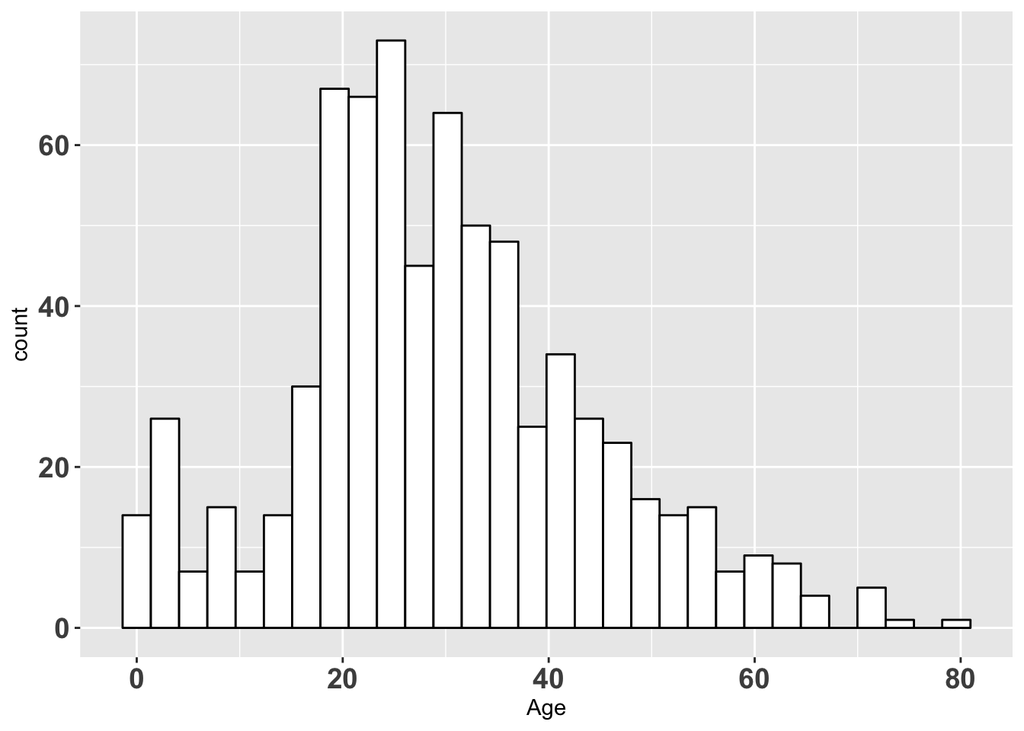

```r
p <- ggplot(datTrain, aes(x=Age))
p <- p + geom_histogram(colour="black", fill="white")
p <- p + theme(axis.text.x=element_text(size=14, face="bold"),
               axis.text.y=element_text(size=14, face="bold"))
plot(p)
```

# histogram (Age_log)

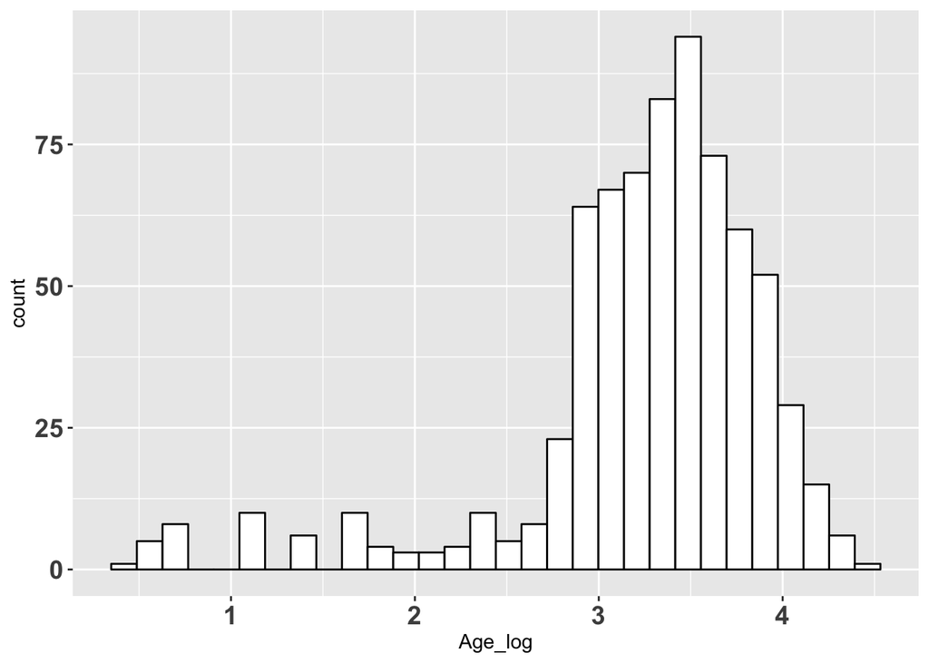

```r
p <- ggplot(datTrain, aes(x=Age_log))
p <- p + geom_histogram(colour="black", fill="white")
p <- p + theme(axis.text.x=element_text(size=14, face="bold"),
               axis.text.y=element_text(size=14, face="bold"))
plot(p)
```

# histogram (Fare)

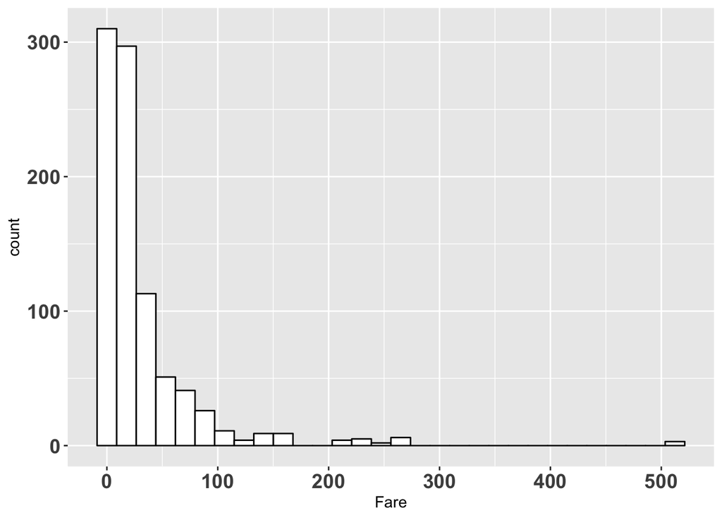

```r
p <- ggplot(datTrain, aes(x=Fare))
p <- p + geom_histogram(colour="black", fill="white")
p <- p + theme(axis.text.x=element_text(size=14, face="bold"),
               axis.text.y=element_text(size=14, face="bold"))
plot(p)
```

# histogram (Fare_log)

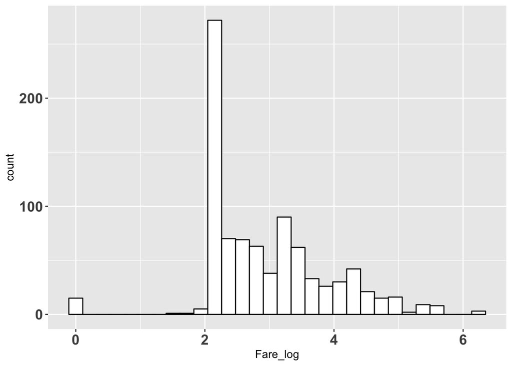

```r
p <- ggplot(datTrain, aes(x=Fare_log))
p <- p + geom_histogram(colour="black", fill="white")
p <- p + theme(axis.text.x=element_text(size=14, face="bold"),
               axis.text.y=element_text(size=14, face="bold"))
plot(p)
```

# boxplot (Age by Sex)

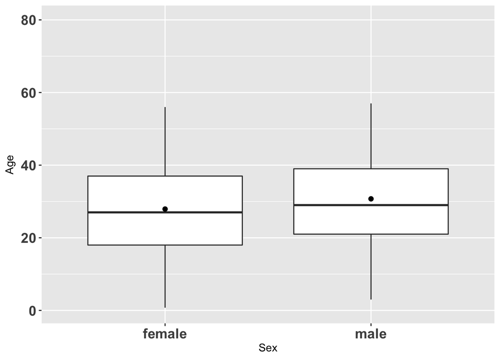

```r
p <- ggplot(datTrain, aes(x=Sex, y=Age, group=Sex))
p <- p + geom_boxplot(outlier.shape=NA, notch=F, coef=1.0)
p <- p + stat_summary(fun.y=mean, geom="point", shape=20, size=3, fill="white", show.legend=FALSE)
p <- p + theme(axis.text.x=element_text(size=14, face="bold"),
               axis.text.y=element_text(size=14, face="bold"))
plot(p)
```

# boxplot (Fare, by Pclass)

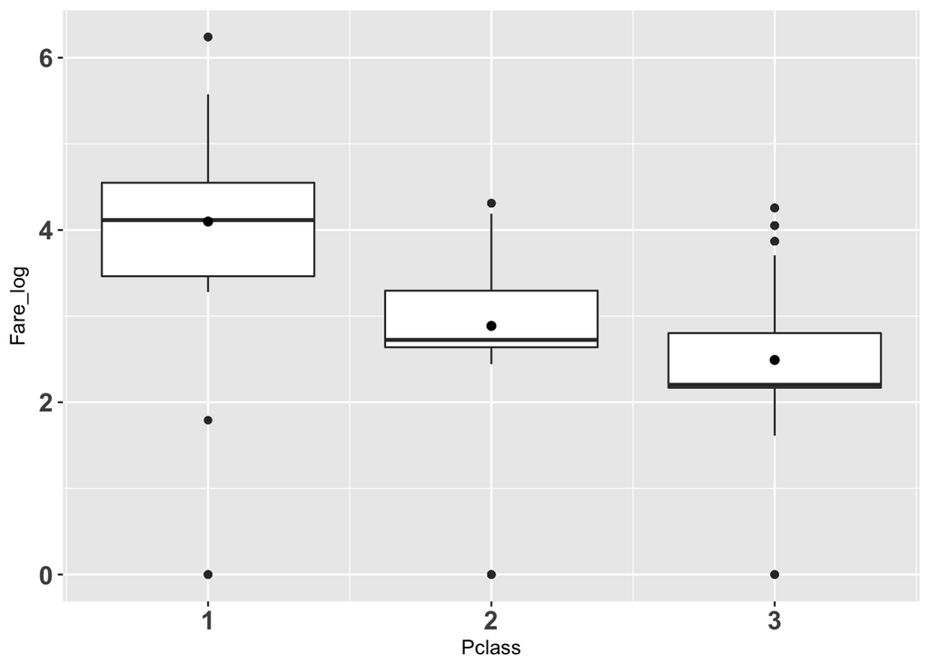

```r
p <- ggplot(datTrain, aes(x=Pclass, y=Fare_log, group=Pclass))
#p <- p + geom_boxplot(outlier.shape=NA, notch=F, coef=1.0)
p <- p + geom_boxplot()
p <- p + stat_summary(fun.y=mean, geom="point", shape=20, size=3, fill="white", show.legend=FALSE)
p <- p + theme(axis.text.x=element_text(size=14, face="bold"),
               axis.text.y=element_text(size=14, face="bold"))
plot(p)
```

# boxplot (Fare_log>2.0, by Pclass)

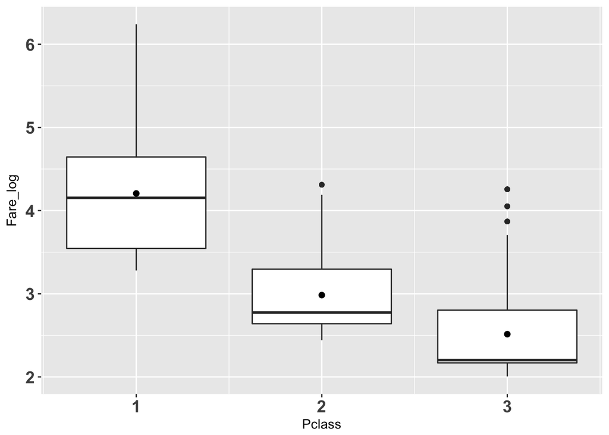

```r
fillFlg_eff <- datTrain[,"Fare_log"]>2.0
datTrain_eff <- datTrain[fillFlg_eff,]

p <- ggplot(datTrain_eff, aes(x=Pclass, y=Fare_log, group=Pclass))
#p <- p + geom_boxplot(outlier.shape=NA, notch=F, coef=1.0)
p <- p + geom_boxplot()
p <- p + stat_summary(fun.y=mean, geom="point", shape=20, size=3, fill="white", show.legend=FALSE)
p <- p + theme(axis.text.x=element_text(size=14, face="bold"),
               axis.text.y=element_text(size=14, face="bold"))
plot(p)
```

# boxplot (Age by Survived)

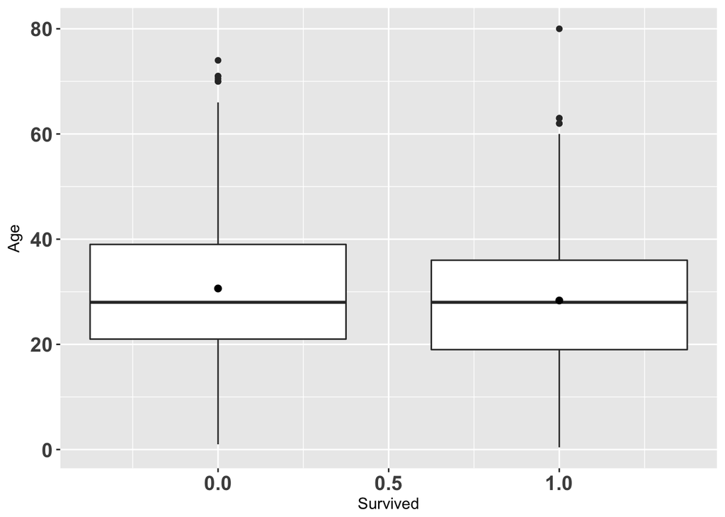

```r
p <- ggplot(datTrain, aes(x=Survived, y=Age, group=Survived))
#p <- p + geom_boxplot(outlier.shape=NA, notch=F, coef=1.0)
p <- p + geom_boxplot()
p <- p + stat_summary(fun.y=mean, geom="point", shape=20, size=3, fill="white", show.legend=FALSE)
p <- p + theme(axis.text.x=element_text(size=14, face="bold"),
               axis.text.y=element_text(size=14, face="bold"))
plot(p)
```

# boxplot (Fare_log > 2.0 by Survived)

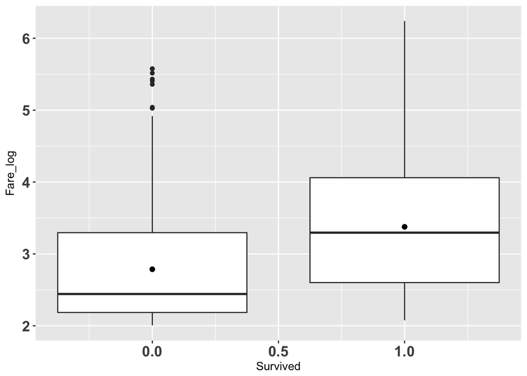

```r
fillFlg_eff <- datTrain[,"Fare_log"]>2.0
datTrain_eff <- datTrain[fillFlg_eff,]

p <- ggplot(datTrain_eff, aes(x=Survived, y=Fare_log, group=Survived))
#p <- p + geom_boxplot(outlier.shape=NA, notch=F, coef=1.0)
p <- p + geom_boxplot()
p <- p + stat_summary(fun.y=mean, geom="point", shape=20, size=3, fill="white", show.legend=FALSE)
p <- p + theme(axis.text.x=element_text(size=14, face="bold"),
               axis.text.y=element_text(size=14, face="bold"))
plot(p)
```

# 相関 (correlation) : {“Age”,“Embarked”}

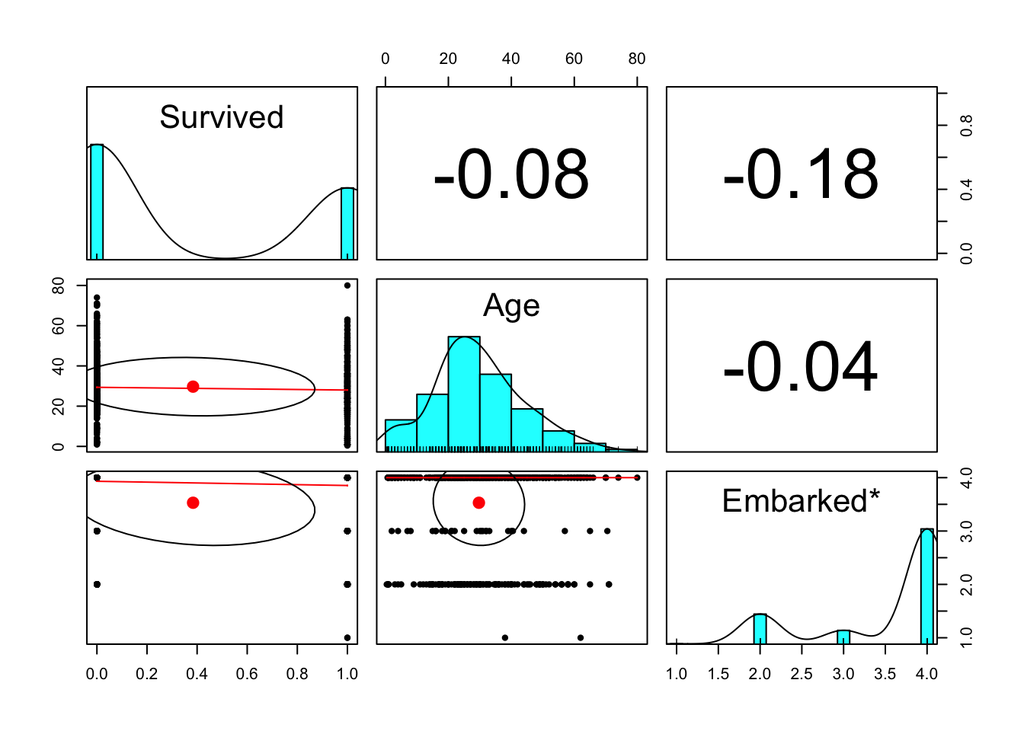

```r
library(psych)
psych::pairs.panels(datTrain[,c("Survived","Age","Embarked")])
```

# 相関 (correlation) : {“Pclass”,“Fare”,“Sex”}

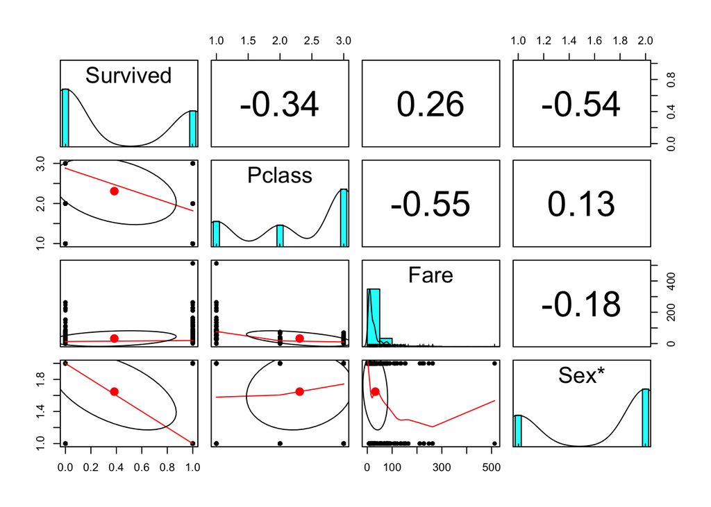

```r
library(psych)
psych::pairs.panels(datTrain[,c("Survived","Pclass","Fare","Sex")])
```

# 相関 (correlation) : {“SibSp”,“Parch”,“Cabin”}

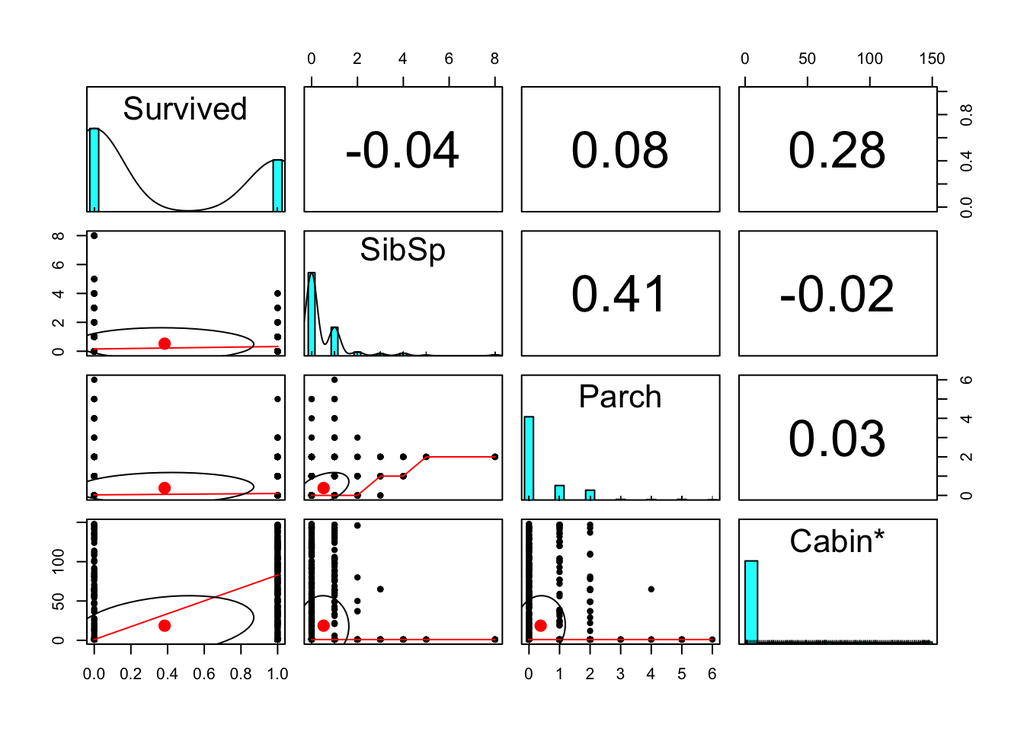

```r
library(psych)
psych::pairs.panels(datTrain[,c("Survived","SibSp","Parch","Cabin")])
```

# 相関 (correlation) : {“Pclass”,“Cabin”}

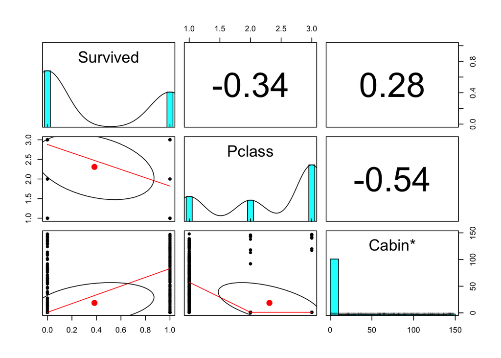

```r
library(psych)
psych::pairs.panels(datTrain[,c("Survived","Pclass","Cabin")])
```